# Projet RDSM

Luweh Adjim Ngarti Exaucé & Laamoumri Yassine & Agbo Merveille

28/12/2020

```r
library(tidyverse)
library(rmarkdown)
library(corrplot)
library(factoextra)
library(rmarkdown)
library(FactoMineR)
```

## Question 1 : Introduction

### a)

Il faut faire une ACP normée car les variables ont des unités différentes comme par exemple : milligrammes, microgrammes, grammes, kilocalories.  
Cela nous permettra d’étudier la notion de corrélation entre les variables.

#### b)

Tout d’abord on charge nos données :

```r
load('data.baby.Rdata')
data_baby_base <- data.baby.comp
data_baby_reduit <- data.baby2.comp
```

Puis on effectue une ACP non normée

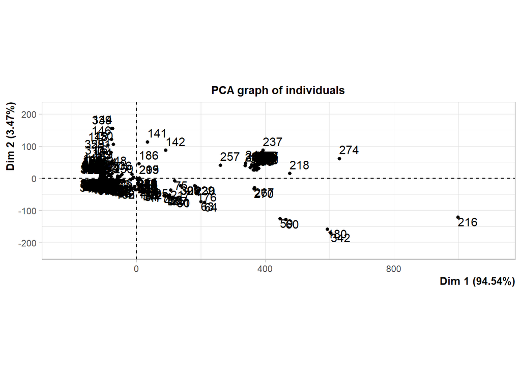

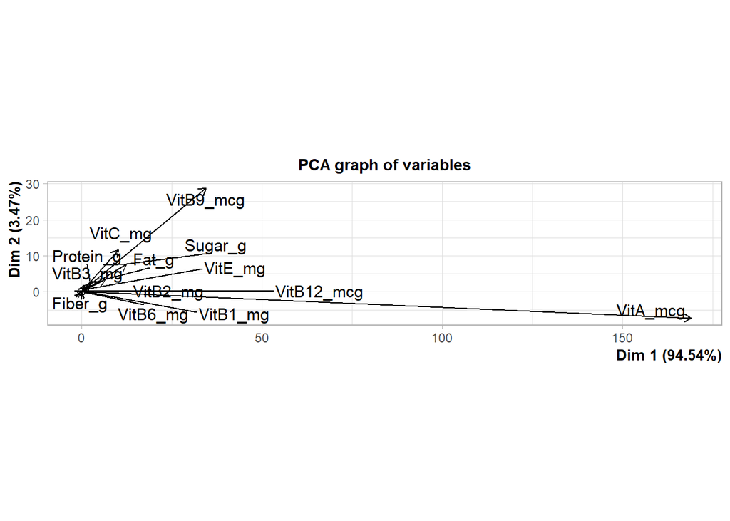

```r
pca.R <- PCA(data_baby_reduit, scale.unit = FALSE)
```

La 1er dimension représente environ 94,54% de l’inertie tandis que la dimension 2 seulement 3,47%. L’information portée par la dimension 2 est insignifiante. De plus, on voit que la variable VitA_mcg est extrêmement correlée avec la dimension 1,ce qui justifie sa position

```r
dimdesc(pca.R)$Dim.1
```

```
## $quanti
##            correlation      p.value
## VitA_mcg     0.9990459 0.000000e+00
## Fat_g        0.7976235 4.737860e-81
## VitE_mg      0.7654555 6.508823e-71
## VitB9_mcg    0.7524435 2.906688e-67
## Sugar_g      0.7436462 6.380024e-65
## VitB12_mcg   0.6727197 4.965499e-49
## Protein_g    0.5358002 2.745927e-28
## VitC_mg      0.3950206 5.733502e-15
## VitB6_mg     0.1932518 2.163841e-04
## VitB2_mg     0.1526082 3.607435e-03
## VitB3_mg     0.1457436 5.465776e-03
## Fiber_g     -0.1915477 2.465291e-04
##
## attr(,"class")
## [1] "condes" "list "
```

On voit que le coefficient de corrlation entre VitA_mcg et la dimension 1 est de 0.999

## Question 2

### a)

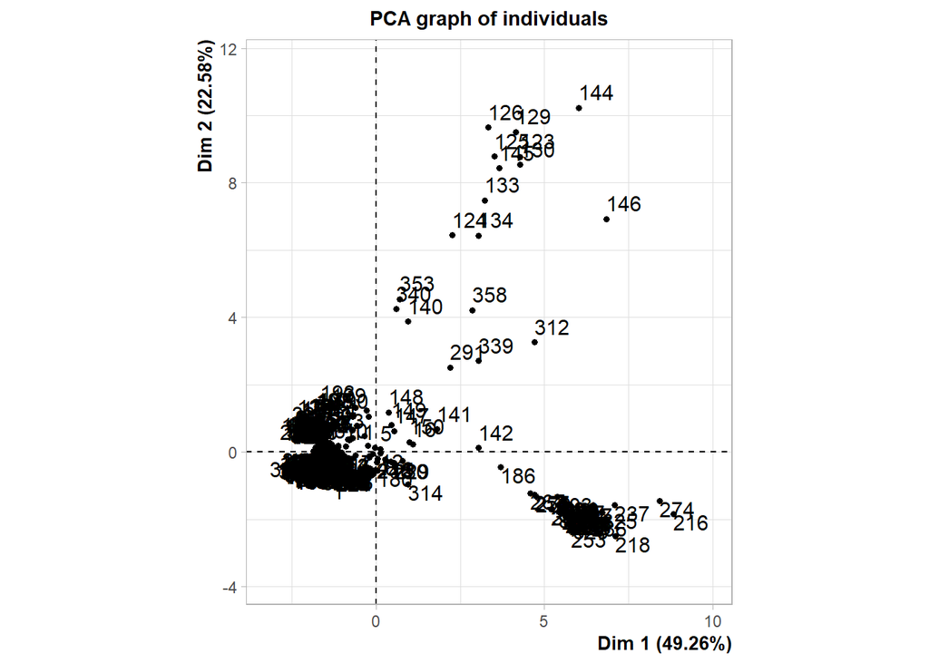

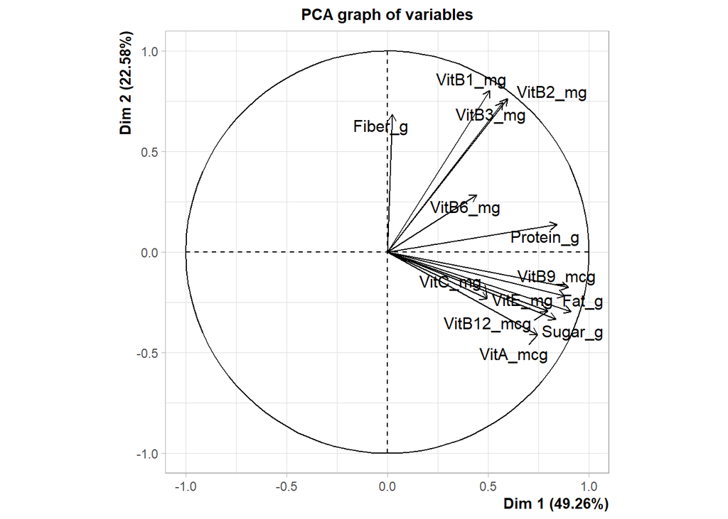

```r
res.PCA<-PCA(data_baby_reduit,scale.unit=TRUE,graph=TRUE)
```

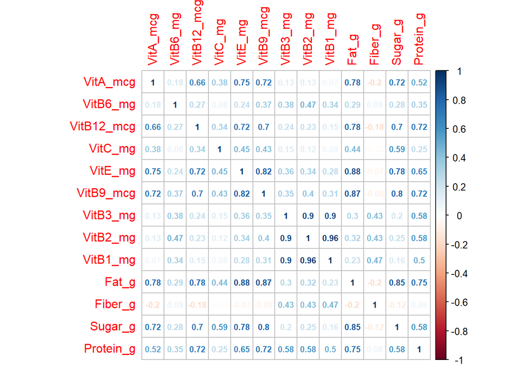

```r
corrplot(cor(data_baby_reduit),method="number",number.cex=0.7)
```

VitB1_mg ,VitB2_mg,VitB3_mg sont fortement correlée entre eux. Il en est de même pour Fat_g, VitE_mg et VitB9_mcg.

#### b)

```r
valeurs_propres<-get_eigenvalue(res.PCA)
valeurs_propres
```

```
##        eigenvalue variance.percent cumulative.variance.percent
## Dim.1  6.40347760       49.2575200                    49.25752
## Dim.2  2.93537473       22.5798056                    71.83733
## Dim.3  0.92384880        7.1065293                    78.94385
## Dim.4  0.75324419        5.7941861                    84.73804
## Dim.5  0.56340697        4.3338998                    89.07194
## Dim.6  0.41500607        3.1923544                    92.26430
## Dim.7  0.26438168        2.0337052                    94.29800
## Dim.8  0.21295069        1.6380823                    95.93608
## Dim.9  0.19777630        1.5213562                    97.45744
## Dim.10 0.14097388        1.0844145                    98.54185
## Dim.11 0.09549263        0.7345587                    99.27641
## Dim.12 0.06433777        0.4949059                    99.77132
## Dim.13 0.02972868        0.2286822                   100.00000
```

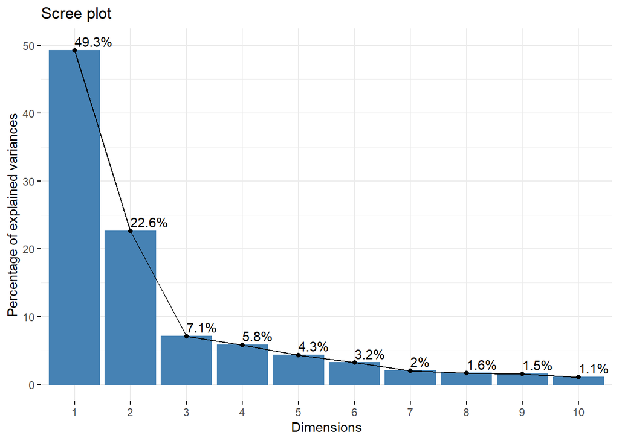

```r
fviz_eig(res.PCA,addlabels=TRUE,ylim=c(0,50))
```

La 1ere dimension explique environ 49% de la variabilité des variables.Les deux premières dimension expliquent environ 72% de la variabilité des variables. Avec la régle de Kaiser, on garde les dimensions ayant une valeur propre supérieur à 1. Dans notre cas, on selectionne nos deux premières dimensions.

##### c)

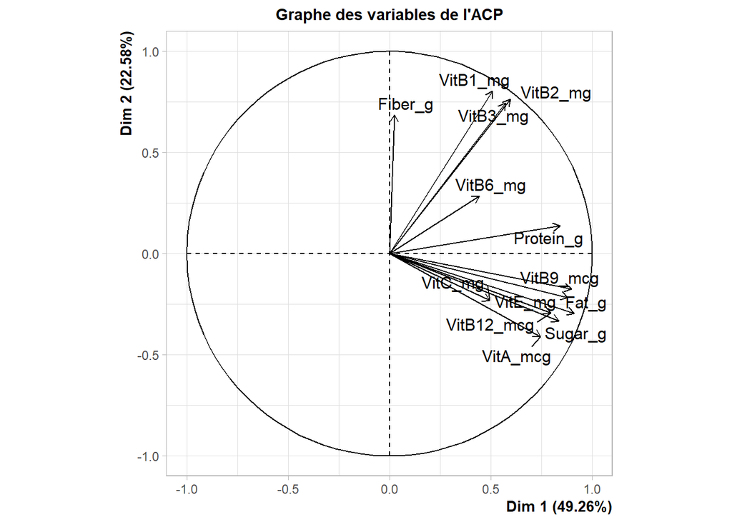

```r
plot.PCA(res.PCA,axes=c(1,2),choix='var',title="Graphe des variables de l'ACP")
```

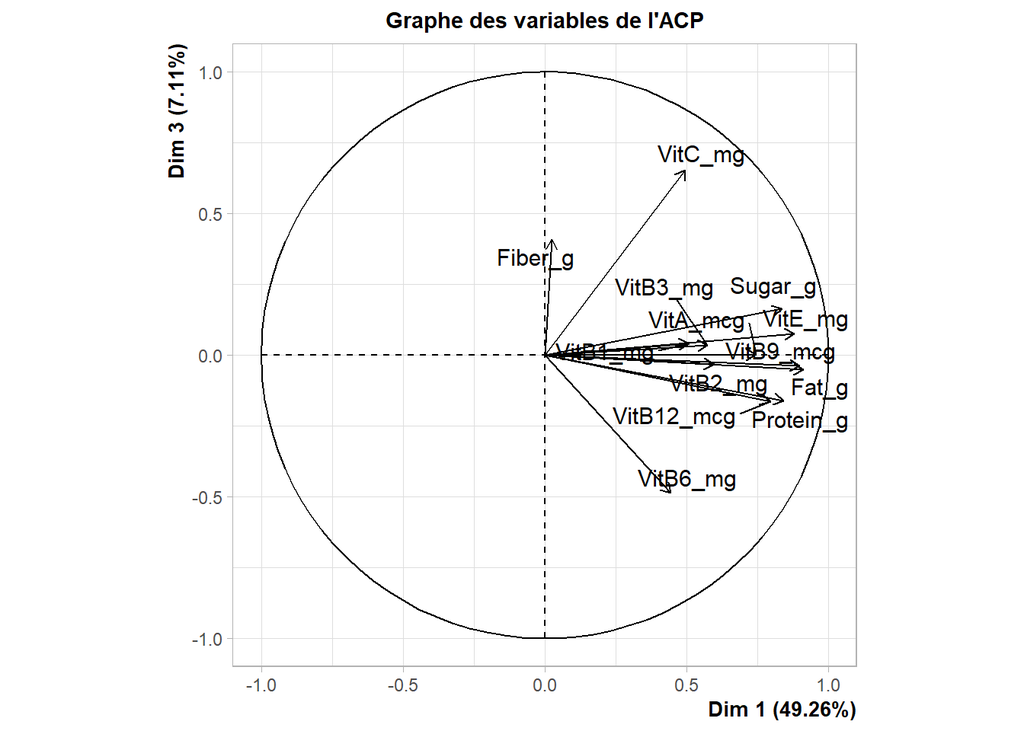

```r
plot.PCA(res.PCA,axes=c(1,3),choix='var',title="Graphe des variables de l'ACP")
```

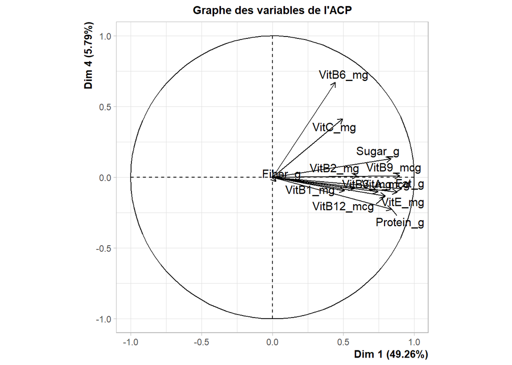

```r
plot.PCA(res.PCA,axes=c(1,4),choix='var',title="Graphe des variables de l'ACP")
```

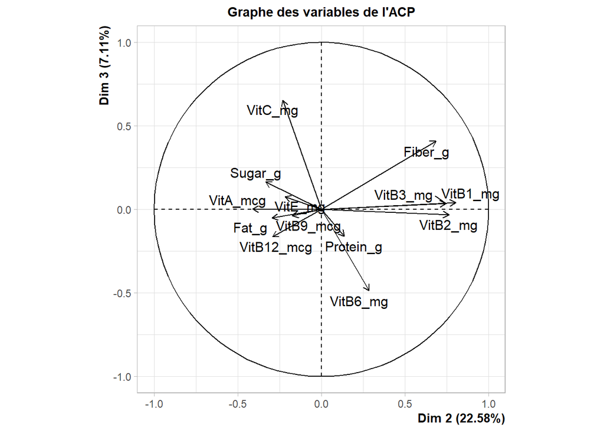

```r
plot.PCA(res.PCA,axes=c(2,3),choix='var',title="Graphe des variables de l'ACP")
```

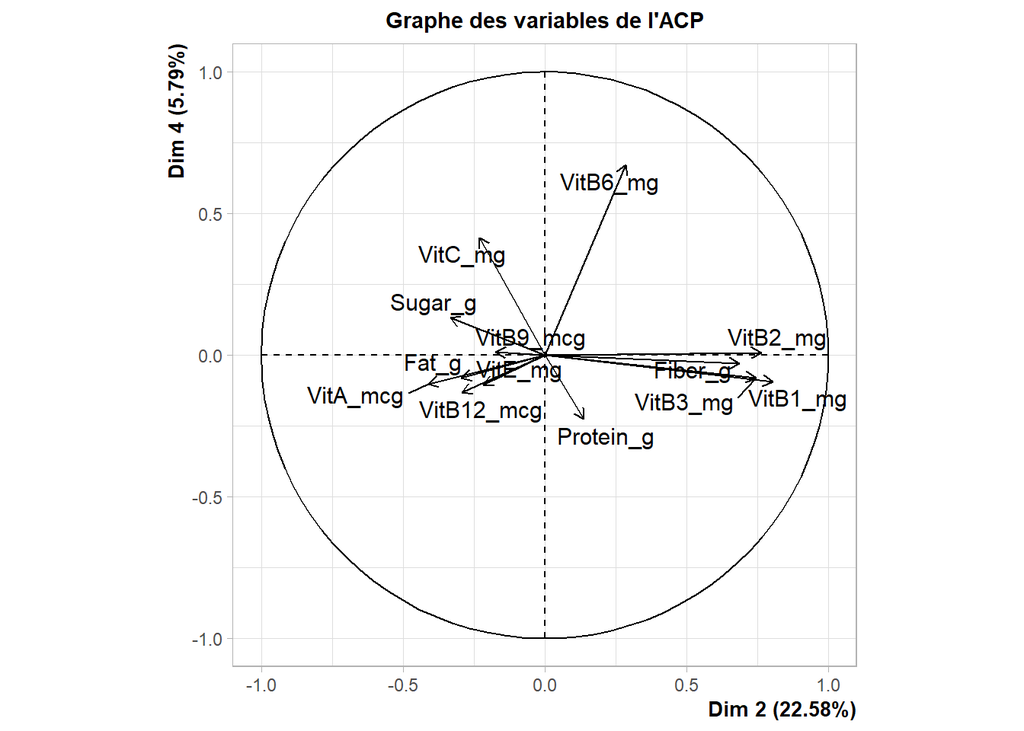

```r
plot.PCA(res.PCA,axes=c(2,4),choix='var',title="Graphe des variables de l'ACP")
```

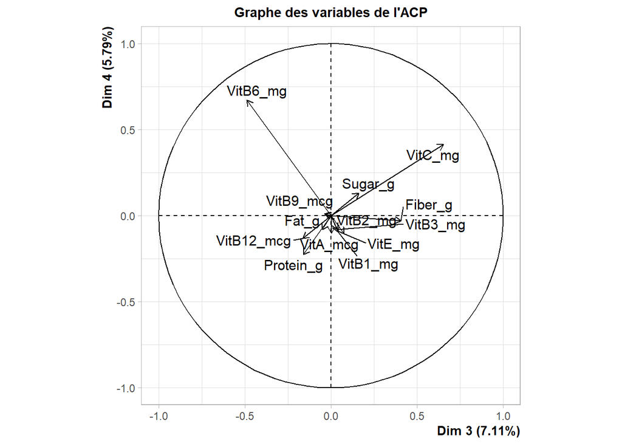

```r
plot.PCA(res.PCA,axes=c(3,4),choix='var',title="Graphe des variables de l'ACP")
```

La meilleure représentation est obtenue en conservant les dimensions 1 et 2. Pratiquement toutes les variables sont bien représentées puisque l’écart type des variables se rapproche de 1. On le voit bien sur ce graphique car le cercle de correlation est de rayon 1. Cependant, les variables VitB6_mg, VitC_mg sont moins bien représentées.

## Question 3

### a)

```r
princomp.R <- princomp(data_baby_reduit,cor=TRUE)

loadings <- princomp.R$loadings

ind <- get_pca_ind(res.PCA)

ind$coord[c(237, 218, 216, 144, 141, 140, 149, 340, 125),]
```

```
##         Dim.1      Dim.2      Dim.3      Dim.4      Dim.5
## 237 7.0927269 -1.5878814  0.5776618  0.5533817 -0.2155418
## 218 7.1020900 -2.5066857  0.5114401 -0.6083595  0.3934937
## 216 8.8310797 -1.8455244 -1.5776273 -0.1918853  1.2410080
## 144 6.0171830 10.2276548  0.1878929 -2.0421959 -0.1838358
## 141 1.8157564  0.6756085  0.0752819 -0.3312609  1.7654376
## 140 0.9549053  3.8729800  1.1479947 -0.3965945  3.1319724
## 149 0.4489068  0.7979775 -0.2538786 -0.4752227  0.1639321
## 340 0.5935591  4.2477724 -0.1416821  0.9093984  2.6131631
## 125 3.5169843  8.7869979  1.4208373 -1.7895915  0.3851678
```

#### b)

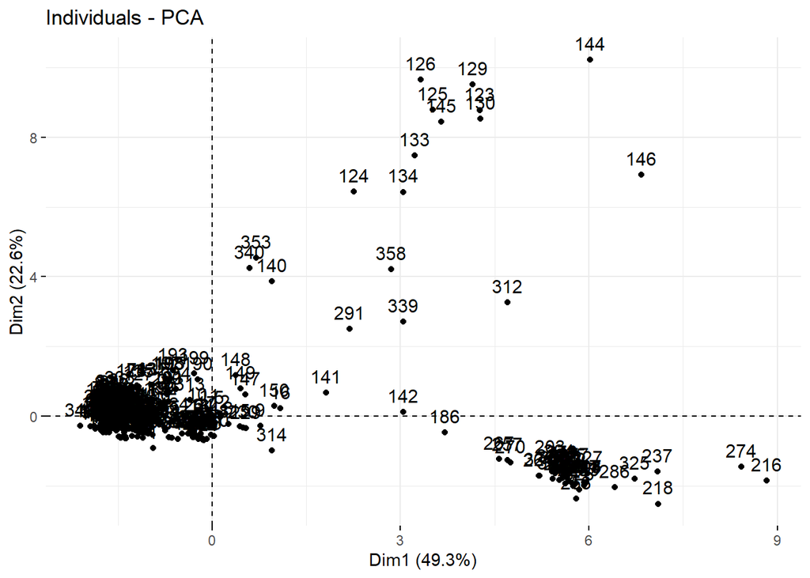

```r
fviz_pca_ind(res.PCA)
```